# p8105_hw6_yh3964

Yirou Hu

2025-11-22

# Problem 1

## Section a

The Washington Post has gathered data on homicides in 50 large U.S. cities and made the data available through a GitHub repository here. You can read their accompanying article here.

- Create a `city_state` variable (e.g. “Baltimore, MD”), and a binary variable indicating whether the homicide is solved.
- Omit cities Dallas, TX; Phoenix, AZ; and Kansas City, MO – these don’t report victim race.
- Also omit Tulsa, AL – this is a data entry mistake.
- For this problem, limit your analysis those for whom victim_race is white or black.
- Be sure that victim_age is numeric.

```r
homicide_data = read_csv("homicide-data.csv") |>
  janitor::clean_names() |>
  mutate(city_state = paste(city, state, sep = ", "),
         resolved = as.numeric(disposition == "Closed by arrest"),
          victim_age = as.numeric(victim_age)) |>
  filter(!city_state %in% c("Dallas, TX", "Phoenix, AZ", "Kansas City, MO", "Tulsa, AL"),
         victim_race %in% c("White", "Black")) |>
  drop_na(victim_age)
```

## Section b

For the city of Baltimore, MD, use the glm function to fit a logistic regression with resolved vs unresolved as the outcome and victim age, sex and race as predictors.

- Save the output of glm as an R object;
- apply the broom::tidy to this object;
- and obtain the estimate and confidence interval of the adjusted odds ratio for solving homicides comparing male victims to female victims keeping all other variables fixed.

```r
baltimore_df = homicide_data |>
  filter(city_state == "Baltimore, MD")

baltimore_glm = glm(resolved ~ victim_age + victim_sex + victim_race,
                     data = baltimore_df,
                     family = binomial())

baltimore_model_results = baltimore_glm |>
  broom::tidy(conf.int = TRUE) |>
  filter(term == "victim_sexMale") |>
  mutate(
    OR = exp(estimate),
    lower_ci = exp(conf.low),
    upper_ci = exp(conf.high)
  )

male_female_or =
  baltimore_model_results |>
  pull(OR)

male_female_ci_lower =
  baltimore_model_results |>
  pull(lower_ci)

male_female_ci_upper =
  baltimore_model_results |>
  pull(upper_ci)
```

### Comments

The estimate of the adjusted odds ratio for solving homicides comparing male victims to female victims keeping all other variables fixed is 0.4255117. These results indicate that the odds of having a solved homicide case for male is approximate 0.43 times the odds for a female. Furthermore, we are 95% confident that the true estimate is between (0.3241908, 0.5575508).

## Section c

Now run glm for each of the cities in your dataset, and extract the adjusted odds ratio (and CI) for solving homicides comparing male victims to female victims.

Do this within a “tidy” pipeline, making use of purrr::map, list columns, and unnest as necessary to create a dataframe with estimated ORs and CIs for each city.

```r
model_glm <- function(df) {
  glm_model = glm(resolved ~ victim_age + victim_sex + victim_race, data = df, family = binomial() )
}

city_results = homicide_data |>
  nest(data = -city_state) |>
  mutate(
    models = map(data, model_glm),
    results = map(models, ~broom::tidy(.x, conf.int = TRUE, exponentiate = TRUE))
  ) |>
  unnest(results) |>
  filter(term == "victim_sexMale") |>
  mutate(
    OR = exp(estimate),
    lower_ci = exp(conf.low),
    upper_ci = exp(conf.high),
    city_state = fct_reorder(city_state, OR)
  )
city_results
```

```
## # A tibble: 47 × 13
##    city_state      data     models term   estimate std.error statistic   p.value
##    <fct>           <list>   <list> <chr>     <dbl>     <dbl>     <dbl>     <dbl>
##  1 Albuquerque, NM <tibble> <glm>  victi…    1.77      0.385  1.48     1.39 e- 1
##  2 Atlanta, GA     <tibble> <glm>  victi…    1.00      0.194  0.000397 1.000e+ 0
##  3 Baltimore, MD   <tibble> <glm>  victi…    0.426     0.138 -6.18     6.26 e-10
##  4 Baton Rouge, LA <tibble> <glm>  victi…    0.381     0.306 -3.15     1.65 e- 3
##  5 Birmingham, AL  <tibble> <glm>  victi…    0.870     0.212 -0.657    5.11 e- 1
##  6 Boston, MA      <tibble> <glm>  victi…    0.674     0.326 -1.21     2.26 e- 1
##  7 Buffalo, NY     <tibble> <glm>  victi…    0.521     0.299 -2.18     2.90 e- 2
##  8 Charlotte, NC   <tibble> <glm>  victi…    0.884     0.236 -0.524    6.00 e- 1
##  9 Chicago, IL     <tibble> <glm>  victi…    0.410     0.102 -8.77     1.86 e-18
## 10 Cincinnati, OH  <tibble> <glm>  victi…    0.400     0.269 -3.41     6.49 e- 4
## # ℹ 37 more rows
## # ℹ 5 more variables: conf.low <dbl>, conf.high <dbl>, OR <dbl>,
## #   lower_ci <dbl>, upper_ci <dbl>
```

Create a plot that shows the estimated ORs and CIs for each city. Organize cities according to estimated OR, and comment on the plot.

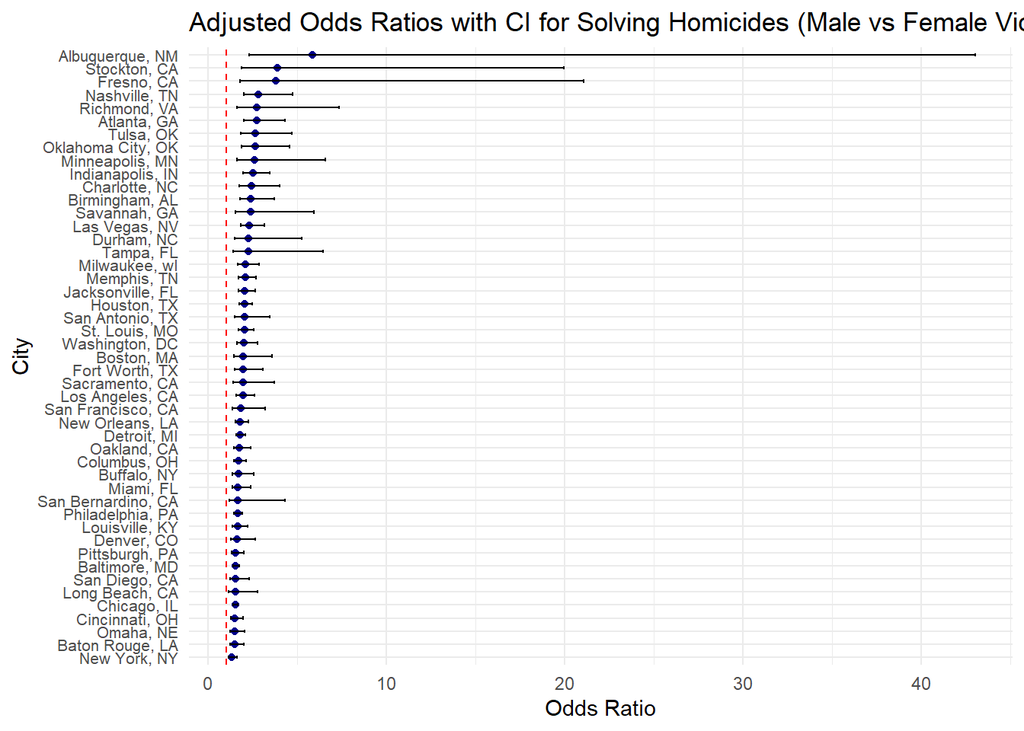

```r
city_results_plot =
  city_results |>
  ggplot(aes(x = OR, y = city_state)) +
  geom_point(color = "darkblue", size = 1.5) +
  geom_errorbar(aes(xmin = lower_ci, xmax = upper_ci), width = 0.25) +
  geom_vline(xintercept = 1, linetype = "dashed", color = "red") +
  labs(
    title = "Adjusted Odds Ratios with CI for Solving Homicides (Male vs Female Victims)",
    x = "Odds Ratio",
    y = "City"
  ) +
  theme_minimal() +
  theme(axis.text.y = element_text(size = 8))

city_results_plot
```

# Problem 2

For this problem, we’ll use the Central Park weather data similar to data we’ve seen elsewhere. The code chunk below (adapted from the course website) will download these data.

```r
data("weather_df")
```

The boostrap is helpful when you’d like to perform inference for a parameter/ value/ summary that doesn’t have an easy-to-write-down distribution in the usual repeated sampling framework. We’ll focus on a simple linear regression with `tmax` as the response with `tmin` and `prcp` as the predictors, and are interested in the distribution of two quantities estimated from these data:

- $\hat{r}^2$
- $\hat{\beta}_1 / \hat{\beta}_2$

Use 5000 bootstrap samples and, for each bootstrap sample, produce estimates of these two quantities.

- Plot the distribution of your estimates, and describe these in words.
- Using the 5000 bootstrap estimates, identify the 2.5% and 97.5% quantiles to provide a 95% confidence interval for $\hat{r}^2$ and $\hat{\beta}_1 / \hat{\beta}_2$.

Note: broom::glance() is helpful for extracting $\hat{r}^2$ from a fitted regression, and `broom::tidy()` (with some additional wrangling) should help in computing $\hat{\beta}_1 / \hat{\beta}_2$.